# Creating a Linear Regression Model to Help Predict the Best Sales Price for Homes in Ames Iowa

Anika Abrahamson,Yaqiong(Juno) Cao, Dexter Nguyen, Michael Ruch, Xinying(Silvia) Sun

September 24, 2020

```r
library(dataQualityR)
library(e1071)
library(mice)
library(corrplot)
library(ggplot2)
library(ggpubr)
library(scales)
library(caret)
library(dplyr)
library(tidyverse)
library(sf)
library(gganimate)
library(MASS)
```

# Outline:

1. Introduction - Business Context
2. Data Preparation 2.1. Data collection 2.2. Data Cleaning 2.3. Data transformation 2.4. Correlation Analysis
3. Exploratory Data Analysis - EDA
4. Modeling 4.1. Modeling with top 10 variables 4.2. Modeling with all variables
5. Evaluation

# 1. Introduction

# 2. Data Preparation

## 2.1. Data collection

## 2.2. Data cleaning

- Data reading

```r
df<-read.delim("AmesHousing.txt")
dim(df)
```

```
## [1] 2930   82
```

- Data overview

```r
str(df)
```

```
## 'data.frame':    2930 obs. of  82 variables:
##  $ Order          : int  1 2 3 4 5 6 7 8 9 10 ...
##  $ PID            : int  526301100 526350040 526351010 526353030 527105010 527105030 527127150 527145080 527146030 527162130 ...
##  $ MS.SubClass    : int  20 20 20 20 60 60 120 120 120 60 ...
##  $ MS.Zoning      : chr  "RL" "RH" "RL" "RL" ...
##  $ Lot.Frontage   : int  141 80 81 93 74 78 41 43 39 60 ...
##  $ Lot.Area       : int  31770 11622 14267 11160 13830 9978 4920 5005 5389 7500 ...
##  $ Street         : chr  "Pave" "Pave" "Pave" "Pave" ...
##  $ Alley          : chr  NA NA NA NA ...
##  $ Lot.Shape      : chr  "IR1" "Reg" "IR1" "Reg" ...
##  $ Land.Contour   : chr  "Lvl" "Lvl" "Lvl" "Lvl" ...
##  $ Utilities      : chr  "AllPub" "AllPub" "AllPub" "AllPub" ...
##  $ Lot.Config     : chr  "Corner" "Inside" "Corner" "Corner" ...
##  $ Land.Slope     : chr  "Gtl" "Gtl" "Gtl" "Gtl" ...
##  $ Neighborhood   : chr  "NAmes" "NAmes" "NAmes" "NAmes" ...
```

[output cut: 68 more lines]

```r
summary(df)
```

```
##      Order             PID             MS.SubClass      MS.Zoning
##  Min.   :   1.0   Min.   :5.263e+08   Min.   : 20.00   Length:2930
##  1st Qu.: 733.2   1st Qu.:5.285e+08   1st Qu.: 20.00   Class :character
##  Median :1465.5   Median :5.355e+08   Median : 50.00   Mode  :character
##  Mean   :1465.5   Mean   :7.145e+08   Mean   : 57.39
##  3rd Qu.:2197.8   3rd Qu.:9.072e+08   3rd Qu.: 70.00
##  Max.   :2930.0   Max.   :1.007e+09   Max.   :190.00
##
##   Lot.Frontage       Lot.Area         Street             Alley
##  Min.   : 21.00   Min.   :  1300   Length:2930        Length:2930
##  1st Qu.: 58.00   1st Qu.:  7440   Class :character   Class :character
##  Median : 68.00   Median :  9436   Mode  :character   Mode  :character
##  Mean   : 69.22   Mean   : 10148
##  3rd Qu.: 80.00   3rd Qu.: 11555
##  Max.   :313.00   Max.   :215245
##  NA's   :490
##   Lot.Shape         Land.Contour        Utilities          Lot.Config
##  Length:2930        Length:2930        Length:2930        Length:2930
##  Class :character   Class :character   Class :character   Class :character
##  Mode  :character   Mode  :character   Mode  :character   Mode  :character
##
##
##
##
##   Land.Slope        Neighborhood       Condition.1        Condition.2
##  Length:2930        Length:2930        Length:2930        Length:2930
##  Class :character   Class :character   Class :character   Class :character
##  Mode  :character   Mode  :character   Mode  :character   Mode  :character
##
##
##
##
##   Bldg.Type         House.Style         Overall.Qual     Overall.Cond
##  Length:2930        Length:2930        Min.   : 1.000   Min.   :1.000
##  Class :character   Class :character   1st Qu.: 5.000   1st Qu.:5.000
##  Mode  :character   Mode  :character   Median : 6.000   Median :5.000
##                                        Mean   : 6.095   Mean   :5.563
##                                        3rd Qu.: 7.000   3rd Qu.:6.000
##                                        Max.   :10.000   Max.   :9.000
##
```

[output cut: 113 more lines]

```
##  Min.   :    0.00   Min.   : 1.000   Min.   :2006   Length:2930
##  1st Qu.:    0.00   1st Qu.: 4.000   1st Qu.:2007   Class :character
##  Median :    0.00   Median : 6.000   Median :2008   Mode  :character
##  Mean   :   50.63   Mean   : 6.216   Mean   :2008
##  3rd Qu.:    0.00   3rd Qu.: 8.000   3rd Qu.:2009
##  Max.   :17000.00   Max.   :12.000   Max.   :2010
##
##  Sale.Condition       SalePrice
##  Length:2930        Min.   : 12789
##  Class :character   1st Qu.:129500
##  Mode  :character   Median :160000
##                     Mean   :180796
##                     3rd Qu.:213500
##                     Max.   :755000
##
```

- Remove 2 columns: Order and PID

```r
df$Order<-NULL # Order column looks like meaningless
df$PID<-NULL # PID column looks like meaningless
```

- change subclass from num to cat

```r
class(df$MS.SubClass)
```

```
## [1] "integer"
```

```r
df$MS.SubClass
```

```
##    [1]  20  20  20  20  60  60 120 120 120  60  60  20  60  20 120  60  50  20
##   [19]  20  20  20  85  60  20  20  20  20  20 120 160 160 160 120 160 120 160
##   [37]  60  20  20  20  20  20  20  20  20 120  20  60 120 120 160  20 120 120
##   [55]  80  60  60  80  60  60  60  20  60  60  60  50  20  20  60  20  60  20
##   [73]  60  60  60 120  60 120 120  60  20  60  30  90  85  20  20  20  20  20
##   [91]  60  60  60 120 160 160 160 160 160  20 160 160 160 160  20  60 120 120
##  [109]  60  20  20  60  20  50  60  20  60  20  20  20  20  20  80  80  85  90
##  [127]  20  50  50  20  30  20  80  20  85  90  20  20  90  20  20  20  20  20
##  [145]  20  20  20  20  50  20  20 190  20  30  20  20  20  50  90  20  80  50
##  [163]  20  50  20  20  20  20  60  50  50  30  30  20  50  30  30  50  45  50
##  [181]  50  30  30  70  50  70 190  20  70 190  70  50  75  30  50  50  50  50
##  [199]  50  50  30  70  50  70  70  90 190 190  70  20  50 190  50  70 190  50
##  [217]  90  90 190  20  20  20  20  60  20  90  60  60  60  20  30  20  40  60
##  [235]  50  30  20  20  50  20  20  20  20  20  60  20  60  60  85  20  20  20
##  [253]  20  60  50  80  85  60  60  20  60  20  20  20  20  60  60  20 120 120
```

[output cut: 148 more lines]

```r
df$MS.SubClass = as.factor(df$MS.SubClass)
class(df$MS.SubClass)
```

```
## [1] "factor"
```

```r
levels(df$MS.SubClass)
```

```
##  [1] "20"  "30"  "40"  "45"  "50"  "60"  "70"  "75"  "80"  "85"  "90"  "120"
## [13] "150" "160" "180" "190"
```

- having a data report for cat and num

```r
num.file <- paste(getwd(), "/dqames_num.csv", sep= "")
cat.file <- paste(getwd(), "/dqames_cat.csv", sep= "")
checkDataQuality(data= df, out.file.num= num.file, out.file.cat= cat.file)
```

```
## Check for numeric variables completed // Results saved to disk // Time difference of 0.06482005 secs
## Check for categorical variables completed // Results saved to disk // Time difference of 0.2772911 secs
```

- num - remove NAs

```r
df=df[which(is.na(df$Mas.Vnr.Area)==FALSE),]
df=df[which(is.na(df$BsmtFin.SF.1)==FALSE),]
df=df[which(is.na(df$BsmtFin.SF.2)==FALSE),]
df=df[which(is.na(df$Bsmt.Unf.SF)==FALSE),]
df=df[which(is.na(df$Total.Bsmt.SF)==FALSE),]
df=df[which(is.na(df$Garage.Yr.Blt)==FALSE),]
df=df[which(is.na(df$Garage.Cars)==FALSE),]
df=df[which(is.na(df$Garage.Area)==FALSE),]
df=df[which(is.na(df$Bsmt.Full.Bath)==FALSE),]
df=df[which(is.na(df$Bsmt.Half.Bath)==FALSE),]
```

- impute missing value by sampling

```r
imputed = mice(df, seed = 169, method = "sample")
micedf = complete(imputed, 3)
df$Lot.Frontage = micedf$Lot.Frontage
```

- cat - remove Alley/pool/fence/misc.feature column

```r
df$Alley<-NULL
df$Pool.QC<-NULL
df$Fence<-NULL
df$Misc.Feature<-NULL
```

- cat - remove NAs for feature other cat culumns

```r
df=df[which(is.na(df$Bsmt.Qual)==FALSE),]
df=df[which(is.na(df$Bsmt.Cond)==FALSE),]
df=df[which(is.na(df$Bsmt.Exposure)==FALSE),]
df=df[which(is.na(df$BsmtFin.Type.1)==FALSE),]
df=df[which(is.na(df$BsmtFin.Type.2)==FALSE),]
df=df[which(is.na(df$Electrical)==FALSE),]
```

- replace the fireplace’s NA with the most frequent level

```r
df$Fireplace.Qu[is.na(df$Fireplace.Qu)] <- "Gd" # I cannot found a better way to deal with the missing cat value
```

- check current data report

```r
num.file <- paste(getwd(), "/dqames_num.csv", sep= "")
cat.file <- paste(getwd(), "/dqames_cat.csv", sep= "")
checkDataQuality(data= df, out.file.num= num.file, out.file.cat= cat.file)
```

```
## Check for numeric variables completed // Results saved to disk // Time difference of 0.1162002 secs
## Check for categorical variables completed // Results saved to disk // Time difference of 0.2766159 secs
```

- Replace contents of two columns: Kitchen_Qual and Bsmt_Qual

```r
df$Kitchen.Qual <- as.character(df$Kitchen.Qual)
df$Kitchen.Qual[df$Kitchen.Qual == "Ex"] <- "Excellent"
df$Kitchen.Qual[df$Kitchen.Qual == "Gd"] <- "Good"
df$Kitchen.Qual[df$Kitchen.Qual == "TA"] <- "Typical"
df$Kitchen.Qual[df$Kitchen.Qual == "Fa"] <- "Fair"
df$Kitchen.Qual[df$Kitchen.Qual == "Po"] <- "Poor"
df$Kitchen.Qual <- as.factor(df$Kitchen.Qual)

df$Bsmt.Qual <- as.character(df$Bsmt.Qual)
df$Bsmt.Qual[df$Bsmt.Qual == "Ex"] <- "Excellent"
df$Bsmt.Qual[df$Bsmt.Qual == "Gd"] <- "Good"
df$Bsmt.Qual[df$Bsmt.Qual == "TA"] <- "Typical"
df$Bsmt.Qual[df$Bsmt.Qual == "Fa"] <- "Fair"
df$Bsmt.Qual[df$Bsmt.Qual == "Po"] <- "Poor"
df$Bsmt.Qual <- as.factor(df$Bsmt.Qual)
```

- Reorder the factor levels of two categorical variables: Kitchen_Qual and Bsmt_Qual: “Excellent”, “Good”, “Fair”, “Typical”, “Poor”

```r
df$Kitchen.Qual <- factor(df$Kitchen.Qual, levels=c("Excellent", "Good", "Fair", "Typical", "Poor"))
df$Bsmt.Qual <- factor(df$Bsmt.Qual, levels=c("Excellent", "Good", "Fair", "Typical", "Poor"))
```

- Replace contents of 4 columns: “Garage.Cars”, “Garage.Area”, “Total.Bsmt.SF”, “Full.Bath”

```r
df$Garage.Cars[df$Garage.Cars == 0] <- 0.01
df$Garage.Area[df$Garage.Area == 0] <- 0.01
df$Total.Bsmt.SF[df$Total.Bsmt.SF == 0] <- 0.01
df$Full.Bath[df$Full.Bath == 0] <- 0.01
```

## 2.3. Data transformation

## 2.3.1. Convert categorical variables to dummies

- Create a set of categorical variable

```r
cate = c("MS.SubClass", "MS.Zoning", "Street", "Lot.Shape", "Land.Contour", "Utilities", "Lot.Config", "Land.Slope", "Neighborhood", "Condition.1", "Condition.2", "Bldg.Type", "House.Style", "Roof.Style", "Roof.Matl", "Exterior.1st", "Exterior.2nd", "Mas.Vnr.Type", "Exter.Qual", "Exter.Cond", "Foundation", "Bsmt.Qual", "Bsmt.Cond", "Bsmt.Exposure", "BsmtFin.Type.1", "BsmtFin.Type.2", "Heating", "Heating.QC", "Central.Air", "Electrical", "Kitchen.Qual", "Functional", "Fireplace.Qu", "Garage.Type", "Garage.Finish", "Garage.Qual", "Garage.Cond", "Paved.Drive", "Sale.Type", "Sale.Condition")
```

- convert categorical variables to dummies

```r
dfcate = df[,cate]
```

- The same code was used for all categorical variables

```r
for(level in unique(dfcate$MS.SubClass)){dfcate[paste("MS.SubClass", level, sep = "_")] <- ifelse(dfcate$MS.SubClass == level, 1, 0)}

for(level in unique(dfcate$MS.Zoning)){dfcate[paste("MS.Zoning", level, sep = "_")] <- ifelse(dfcate$MS.Zoning == level, 1, 0)}

for(level in unique(dfcate$Street)){dfcate[paste("Street", level, sep = "_")] <- ifelse(dfcate$Street == level, 1, 0)}

for(level in unique(dfcate$Lot.Shape)){dfcate[paste("Lot.Shape", level, sep = "_")] <- ifelse(dfcate$Lot.Shape == level, 1, 0)}

for(level in unique(dfcate$Land.Contour)){dfcate[paste("Land.Contour", level, sep = "_")] <- ifelse(dfcate$Land.Contour == level, 1, 0)}

for(level in unique(dfcate$Utilities)){dfcate[paste("Utilities", level, sep = "_")] <- ifelse(dfcate$Utilities == level, 1, 0)}

for(level in unique(dfcate$Lot.Config)){dfcate[paste("Lot.Config", level, sep = "_")] <- ifelse(dfcate$Lot.Config == level, 1, 0)}

for(level in unique(dfcate$Land.Slope)){dfcate[paste("Land.Slope", level, sep = "_")] <- ifelse(dfcate$Land.Slope == level, 1, 0)}

for(level in unique(dfcate$Neighborhood)){dfcate[paste("Neighborhood", level, sep = "_")] <- ifelse(dfcate$Neighborhood == level, 1, 0)}

for(level in unique(dfcate$Condition.1)){dfcate[paste("Condition.1", level, sep = "_")] <- ifelse(dfcate$Condition.1 == level, 1, 0)}

for(level in unique(dfcate$Condition.2)){dfcate[paste("Condition.2", level, sep = "_")] <- ifelse(dfcate$Condition.2 == level, 1, 0)}

for(level in unique(dfcate$Bldg.Type)){dfcate[paste("Bldg.Type", level, sep = "_")] <- ifelse(dfcate$Bldg.Type == level, 1, 0)}

for(level in unique(dfcate$House.Style)){dfcate[paste("House.Style", level, sep = "_")] <- ifelse(dfcate$House.Style == level, 1, 0)}

for(level in unique(dfcate$Roof.Style)){dfcate[paste("Roof.Style", level, sep = "_")] <- ifelse(dfcate$Roof.Style == level, 1, 0)}

for(level in unique(dfcate$MRoof.Matl)){dfcate[paste("Roof.Matl", level, sep = "_")] <- ifelse(dfcate$Roof.Matl == level, 1, 0)}

for(level in unique(dfcate$Exterior.1st)){dfcate[paste("Exterior.1st", level, sep = "_")] <- ifelse(dfcate$Exterior.1st == level, 1, 0)}

for(level in unique(dfcate$Exterior.2nd)){dfcate[paste("Exterior.2nd", level, sep = "_")] <- ifelse(dfcate$Exterior.2nd == level, 1, 0)}

for(level in unique(dfcate$Mas.Vnr.Type)){dfcate[paste("Mas.Vnr.Type", level, sep = "_")] <- ifelse(dfcate$Mas.Vnr.Type == level, 1, 0)}

for(level in unique(dfcate$Exter.Qual)){dfcate[paste("Exter.Qual", level, sep = "_")] <- ifelse(dfcate$Exter.Qual == level, 1, 0)}

for(level in unique(dfcate$Exter.Cond)){dfcate[paste("Exter.Cond", level, sep = "_")] <- ifelse(dfcate$Exter.Cond == level, 1, 0)}

for(level in unique(dfcate$Foundation)){dfcate[paste("Foundation", level, sep = "_")] <- ifelse(dfcate$Foundation == level, 1, 0)}

for(level in unique(dfcate$Bsmt.Qual)){dfcate[paste("Bsmt.Qual", level, sep = "_")] <- ifelse(dfcate$Bsmt.Qual == level, 1, 0)}

for(level in unique(dfcate$Bsmt.Cond)){dfcate[paste("Bsmt.Cond", level, sep = "_")] <- ifelse(dfcate$Bsmt.Cond == level, 1, 0)}

for(level in unique(dfcate$Bsmt.Exposure)){dfcate[paste("Bsmt.Exposure", level, sep = "_")] <- ifelse(dfcate$Bsmt.Exposure == level, 1, 0)}

for(level in unique(dfcate$BsmtFin.Type.1)){dfcate[paste("BsmtFin.Type.1", level, sep = "_")] <- ifelse(dfcate$BsmtFin.Type.1 == level, 1, 0)}

for(level in unique(dfcate$BsmtFin.Type.2)){dfcate[paste("BsmtFin.Type.2", level, sep = "_")] <- ifelse(dfcate$BsmtFin.Type.2 == level, 1, 0)}

for(level in unique(dfcate$Heating)){dfcate[paste("Heating", level, sep = "_")] <- ifelse(dfcate$Heating == level, 1, 0)}

for(level in unique(dfcate$Heating.QC)){dfcate[paste("Heating.QC", level, sep = "_")] <- ifelse(dfcate$Heating.QC == level, 1, 0)}

for(level in unique(dfcate$Central.Air)){dfcate[paste("Central.Air", level, sep = "_")] <- ifelse(dfcate$Central.Air == level, 1, 0)}

for(level in unique(dfcate$Electrical)){dfcate[paste("Electrical", level, sep = "_")] <- ifelse(dfcate$Electrical == level, 1, 0)}

for(level in unique(dfcate$Kitchen.Qual)){dfcate[paste("Kitchen.Qual", level, sep = "_")] <- ifelse(dfcate$Kitchen.Qual == level, 1, 0)}

for(level in unique(dfcate$Functional)){dfcate[paste("Functional", level, sep = "_")] <- ifelse(dfcate$Functional == level, 1, 0)}

for(level in unique(dfcate$Fireplace.Qu)){dfcate[paste("Fireplace.Qu", level, sep = "_")] <- ifelse(dfcate$Fireplace.Qu == level, 1, 0)}

for(level in unique(dfcate$Garage.Type)){dfcate[paste("Garage.Type", level, sep = "_")] <- ifelse(dfcate$Garage.Type == level, 1, 0)}

for(level in unique(dfcate$Garage.Finish)){dfcate[paste("Garage.Finish", level, sep = "_")] <- ifelse(dfcate$Garage.Finish == level, 1, 0)}

for(level in unique(dfcate$Garage.Qual)){dfcate[paste("Garage.Qual", level, sep = "_")] <- ifelse(dfcate$Garage.Qual == level, 1, 0)}

for(level in unique(dfcate$Garage.Cond)){dfcate[paste("Garage.Cond", level, sep = "_")] <- ifelse(dfcate$Garage.Cond == level, 1, 0)}

for(level in unique(dfcate$Paved.Drive)){dfcate[paste("Paved.Drive", level, sep = "_")] <- ifelse(dfcate$Paved.Drive == level, 1, 0)}

for(level in unique(dfcate$Sale.Type)){dfcate[paste("Sale.Type", level, sep = "_")] <- ifelse(dfcate$Sale.Type == level, 1, 0)}

for(level in unique(dfcate$Sale.Condition)){dfcate[paste("Sale.Condition", level, sep = "_")] <- ifelse(dfcate$Sale.Condition == level, 1, 0)}
```

## 2.3.2. Create a set of numerical variable

```r
numer = c("Lot.Frontage", "Lot.Area", "Overall.Qual", "Overall.Cond",
          "Year.Built", "Year.Remod.Add", "Mas.Vnr.Area", "BsmtFin.SF.1",
          "BsmtFin.SF.2", "Bsmt.Unf.SF", "Total.Bsmt.SF", "X1st.Flr.SF",
          "X2nd.Flr.SF", "Low.Qual.Fin.SF", "Gr.Liv.Area", "Bsmt.Full.Bath",
          "Bsmt.Half.Bath", "Full.Bath", "Half.Bath", "Bedroom.AbvGr",
          "Kitchen.AbvGr", "TotRms.AbvGrd", "Fireplaces", "Garage.Yr.Blt",
          "Garage.Cars", "Garage.Area", "Wood.Deck.SF", "Open.Porch.SF",
          "Enclosed.Porch", "X3Ssn.Porch", "Screen.Porch", "Pool.Area",
          "Misc.Val", "Mo.Sold", "Yr.Sold", "SalePrice")
dfnum = df[,numer]
```

## 2.3.3. Create a new dataframe combining numerical and dummy variables

```r
dfnew <- cbind(dfnum, dfcate[,41:297])
dim(dfnew)
```

```
## [1] 2683  293
```

## 2.4. Correlation analysis

- Build correlation atts with sale price

```r
correlations <- cor(dfnew)
price_cor <- correlations[,36]
summary(price_cor)
```

```
##     Min.  1st Qu.   Median     Mean  3rd Qu.     Max.
## -0.59462 -0.07401 -0.01386  0.03397  0.09058  1.00000
```

- correlation atts - price - Keep top 10 variables with the highest correlation

```r
head(price_cor[order(price_cor, decreasing = TRUE)],11)
```

```
##              SalePrice           Overall.Qual            Gr.Liv.Area
##              1.0000000              0.7929786              0.7157425
##            Garage.Cars            Garage.Area            X1st.Flr.SF
##              0.6525662              0.6335775              0.6302305
##          Total.Bsmt.SF    Bsmt.Qual_Excellent              Full.Bath
##              0.6289149              0.5964918              0.5555836
## Kitchen.Qual_Excellent             Year.Built
##              0.5457159              0.5456608
```

- correlation mattrix

```r
top10 = c("Overall.Qual", "Gr.Liv.Area", "Garage.Cars", "Garage.Area", "X1st.Flr.SF", "Total.Bsmt.SF", "Full.Bath", "Year.Built", "Bsmt.Qual_Excellent", "Kitchen.Qual_Excellent","SalePrice")
dftop = dfnew[,top10]
dftop <- cor(dftop)
dftop
```

```
##                        Overall.Qual Gr.Liv.Area Garage.Cars Garage.Area
## Overall.Qual              1.0000000   0.5794342   0.5947371   0.5405298
## Gr.Liv.Area               0.5794342   1.0000000   0.5183378   0.5038698
## Garage.Cars               0.5947371   0.5183378   1.0000000   0.8461278
## Garage.Area               0.5405298   0.5038698   0.8461278   1.0000000
## X1st.Flr.SF               0.4935022   0.5518407   0.4546958   0.5139227
## Total.Bsmt.SF             0.5164510   0.4607339   0.4670238   0.5221695
## Full.Bath                 0.5465033   0.6276989   0.5312132   0.4356497
## Year.Built                0.5945998   0.2450880   0.5336348   0.4568981
## Bsmt.Qual_Excellent       0.4987172   0.3470631   0.3992977   0.4014723
## Kitchen.Qual_Excellent    0.4560061   0.3250397   0.3144141   0.3352047
## SalePrice                 0.7929786   0.7157425   0.6525662   0.6335775
##                        X1st.Flr.SF Total.Bsmt.SF Full.Bath Year.Built
## Overall.Qual             0.4935022     0.5164510 0.5465033  0.5945998
## Gr.Liv.Area              0.5518407     0.4607339 0.6276989  0.2450880
## Garage.Cars              0.4546958     0.4670238 0.5312132  0.5336348
## Garage.Area              0.5139227     0.5221695 0.4356497  0.4568981
## X1st.Flr.SF              1.0000000     0.8859617 0.3610179  0.3044804
## Total.Bsmt.SF            0.8859617     1.0000000 0.3459944  0.4027773
## Full.Bath                0.3610179     0.3459944 1.0000000  0.4916139
## Year.Built               0.3044804     0.4027773 0.4916139  1.0000000
## Bsmt.Qual_Excellent      0.4096542     0.4417961 0.2570120  0.3311771
## Kitchen.Qual_Excellent   0.3751630     0.3936386 0.1909912  0.2245576
## SalePrice                0.6302305     0.6289149 0.5555836  0.5456608
##                        Bsmt.Qual_Excellent Kitchen.Qual_Excellent SalePrice
## Overall.Qual                     0.4987172              0.4560061 0.7929786
## Gr.Liv.Area                      0.3470631              0.3250397 0.7157425
## Garage.Cars                      0.3992977              0.3144141 0.6525662
## Garage.Area                      0.4014723              0.3352047 0.6335775
## X1st.Flr.SF                      0.4096542              0.3751630 0.6302305
## Total.Bsmt.SF                    0.4417961              0.3936386 0.6289149
## Full.Bath                        0.2570120              0.1909912 0.5555836
## Year.Built                       0.3311771              0.2245576 0.5456608
## Bsmt.Qual_Excellent              1.0000000              0.5720133 0.5964918
## Kitchen.Qual_Excellent           0.5720133              1.0000000 0.5457159
## SalePrice                        0.5964918              0.5457159 1.0000000
```

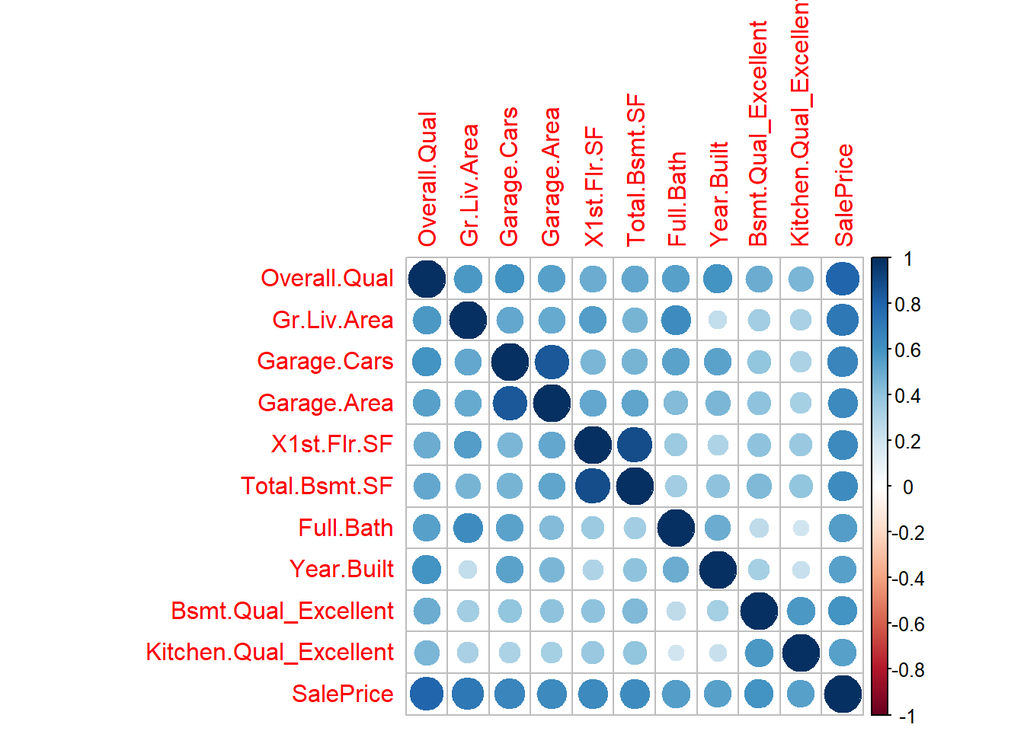

```r
corrplot(dftop, na.label = "NA")
```

So we have 10 variables which belongs to belows types: - Numeric: Overall.Qual, Gr.Liv.Area, Garage.Cars, Garage.Area, X1st.Flr.SF, Total.Bsmt.SF, Full.Bath , Year.Built - Dummy varivales: Bsmt.Qual_Ex, Kitchen.Qual_Ex - Categories to be considered: Bsmt.Qual, Kitchen.Qual

# 3. Exploratory Data Analysis - EDA

## 3.1. Overall SalePrice

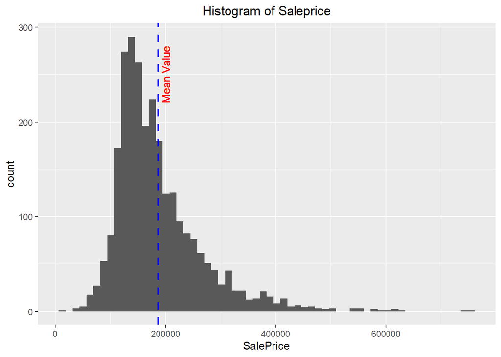

```r
g1 <- ggplot(df, aes(SalePrice))+
  geom_histogram(bins=60) +
  labs(title = "Histogram of Saleprice") +
  theme(plot.title=element_text(hjust=0.5)) +
  geom_vline(aes(xintercept=mean(SalePrice)), color="blue", linetype="dashed", size=1) +
  geom_text(aes(x=190000, label="Mean Value", y=250), colour="red", angle=90, vjust = 1.2, text=element_text(size=11))
g1
```

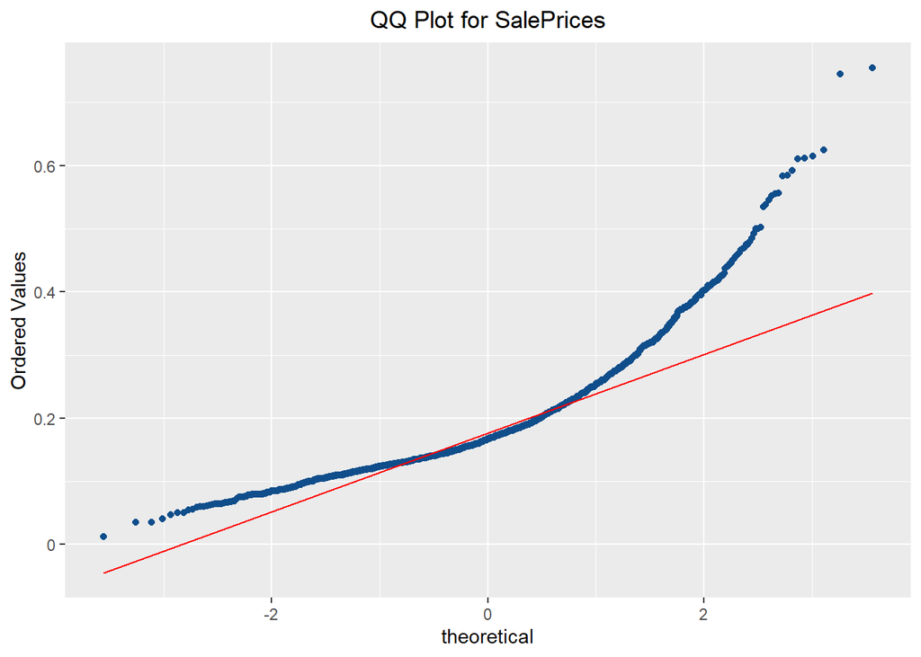

```r
ggplot(df, aes(sample=SalePrice)) +
  stat_qq(color="dodgerblue4") +
  stat_qq_line(color="red") +
  scale_y_continuous(labels=function(y){y/10^6}) +
  labs(title="QQ Plot for SalePrices", y="Ordered Values") +
  theme(plot.title=element_text(hjust=0.5))
```

- Log transformation - SalePrice

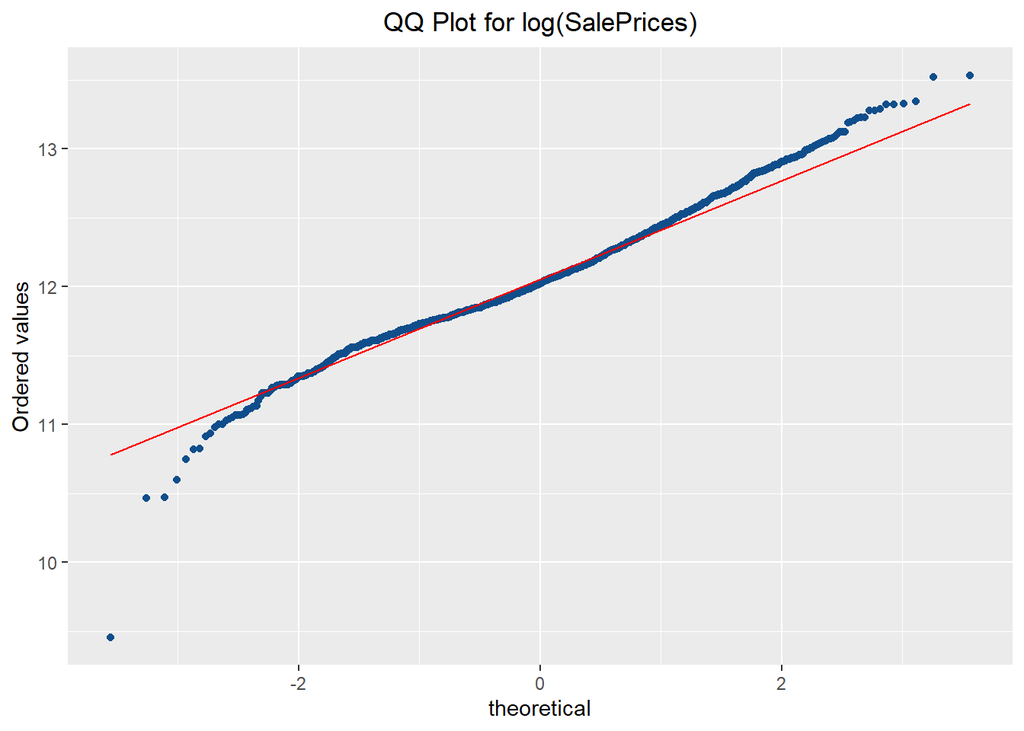

```r
ggplot(df, aes(sample=log(SalePrice))) +
  stat_qq(color="dodgerblue4") +
  stat_qq_line(color="red") +
  labs(title="QQ Plot for log(SalePrices)", y="Ordered values") +
  theme(plot.title=element_text(hjust=0.5))
```

- New Overall SalePrice

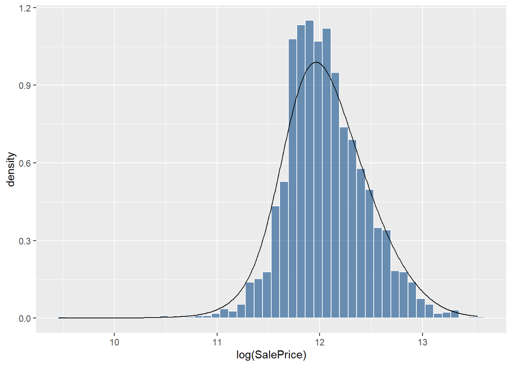

```r
ggplot(df, aes(log(SalePrice))) +
  geom_histogram(aes(y=..density..),
                 bins=50,
                 fill="dodgerblue4",
                 alpha=0.6,
                 color="white") +
  geom_density(adjust=3)
```

- Bsmt.Qual and Kitchen.Qual

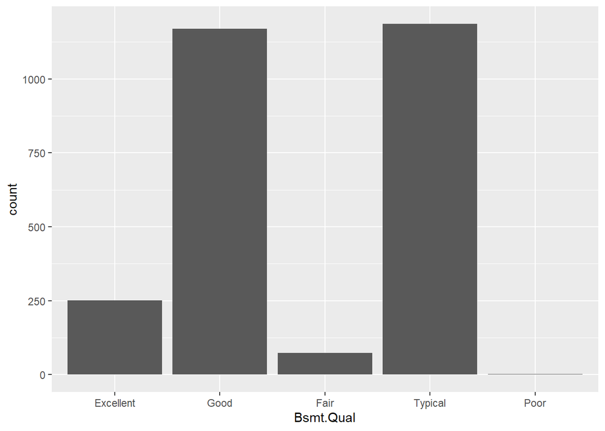

```r
d1 <- ggplot(data.frame(df), aes(x=Bsmt.Qual)) +
  geom_bar()
d1
```

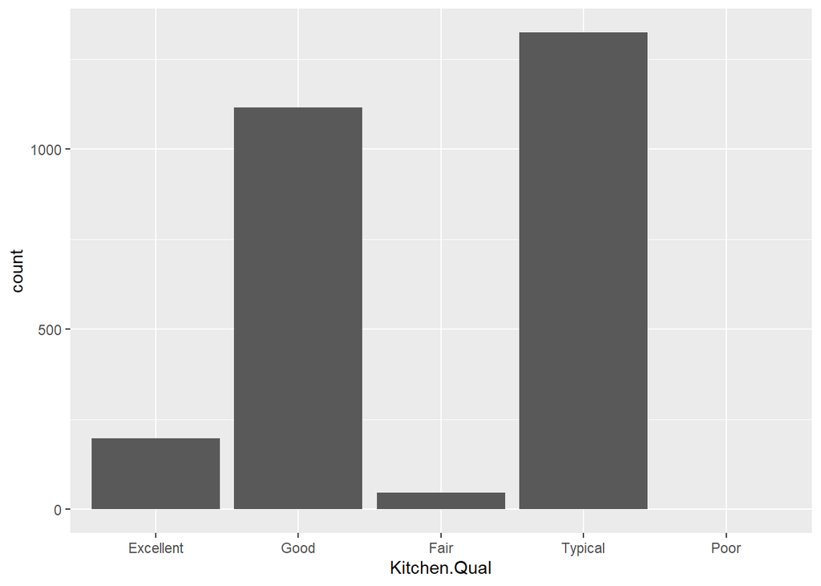

```r
d2 <- ggplot(data.frame(df), aes(x=Kitchen.Qual)) +
  geom_bar()
d2
```

## 3.2. Plotting the marginal distributions of key categorical quantities of interest

- Bsmt.Qual and Kitchen.Qual

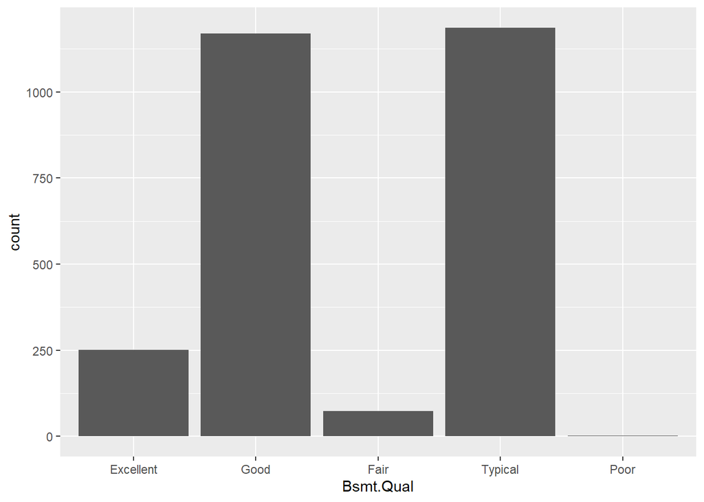

```r
d1 <- ggplot(data.frame(df), aes(x=Bsmt.Qual)) +
  geom_bar()
d1
```

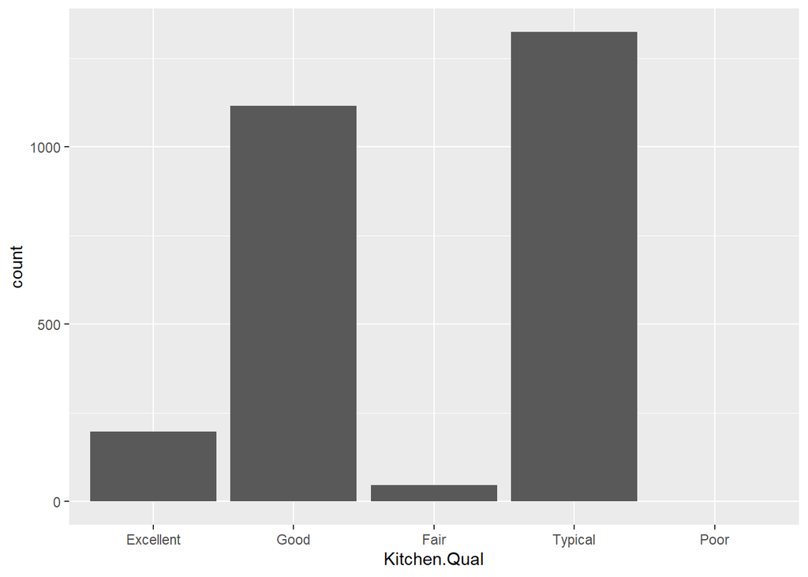

```r
d2 <- ggplot(data.frame(df), aes(x=Kitchen.Qual)) +
  geom_bar()
d2
```

- Bsmt.Qual and Kitchen.Qual in relationship with SalePrice

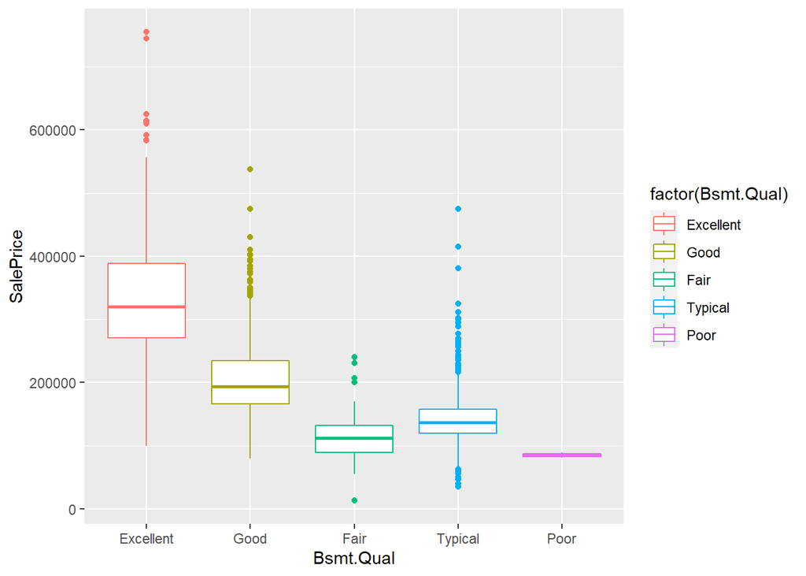

```r
b1 <- ggplot(df, aes(x = Bsmt.Qual, y = SalePrice)) +
    geom_boxplot(aes(color = factor(Bsmt.Qual)))
b1
```

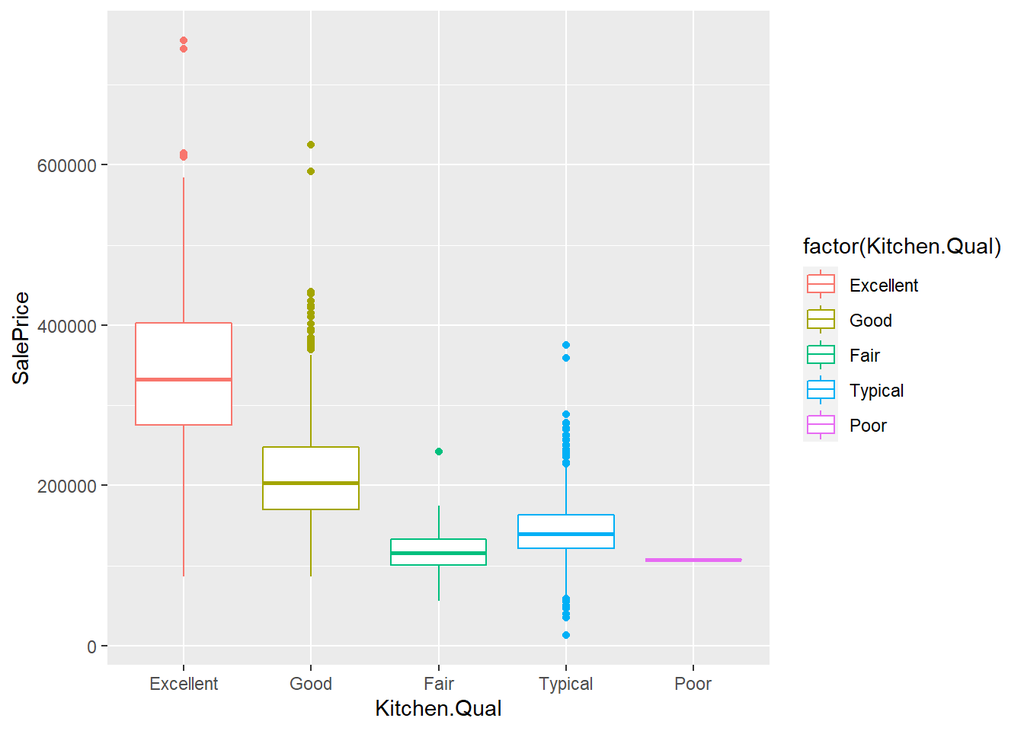

```r
b2 <- ggplot(df, aes(x = Kitchen.Qual, y = SalePrice)) +
    geom_boxplot(aes(color = factor(Kitchen.Qual)))
b2
```

## 3.3. Plotting the marginal distributions of key numerical quantities of interest

Overall.Qual, Gr.Liv.Area, Garage.Cars, Garage.Area, X1st.Flr.SF, Total.Bsmt.SF, Full.Bath, Year.Built

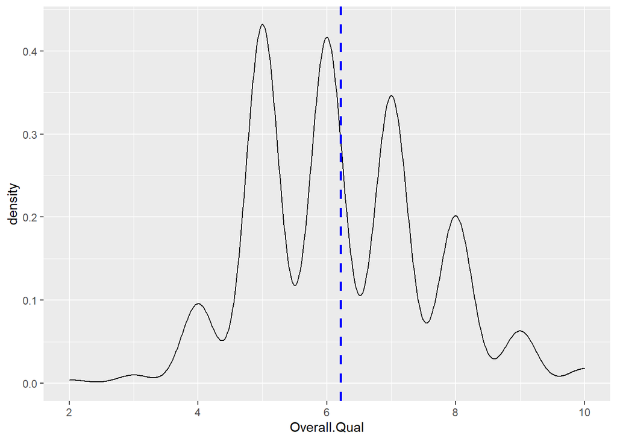

```r
p1 <- ggplot(df, aes(x=Overall.Qual)) +
  geom_density()
p1 + geom_vline(aes(xintercept=mean(Overall.Qual)),
            color="blue", linetype="dashed", size=1)
```

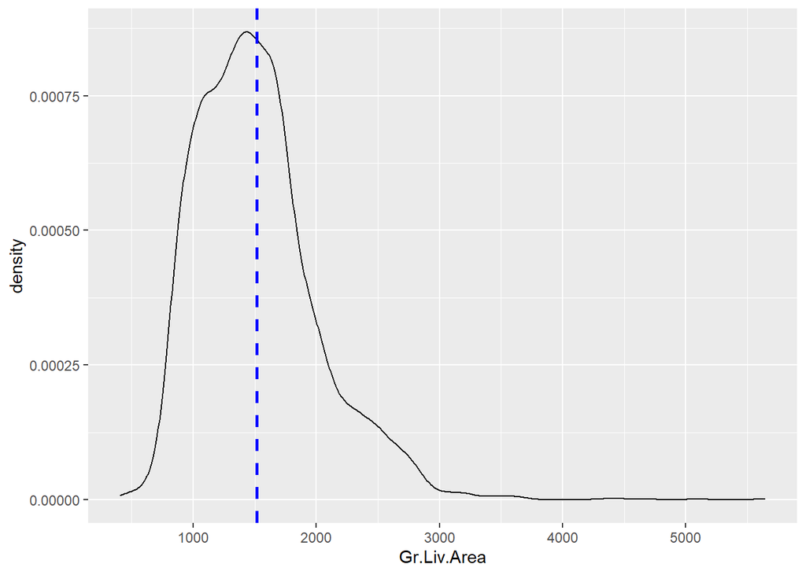

```r
p2 <- ggplot(df, aes(x=Gr.Liv.Area)) +
  geom_density()
p2 + geom_vline(aes(xintercept=mean(Gr.Liv.Area)),
            color="blue", linetype="dashed", size=1)
```

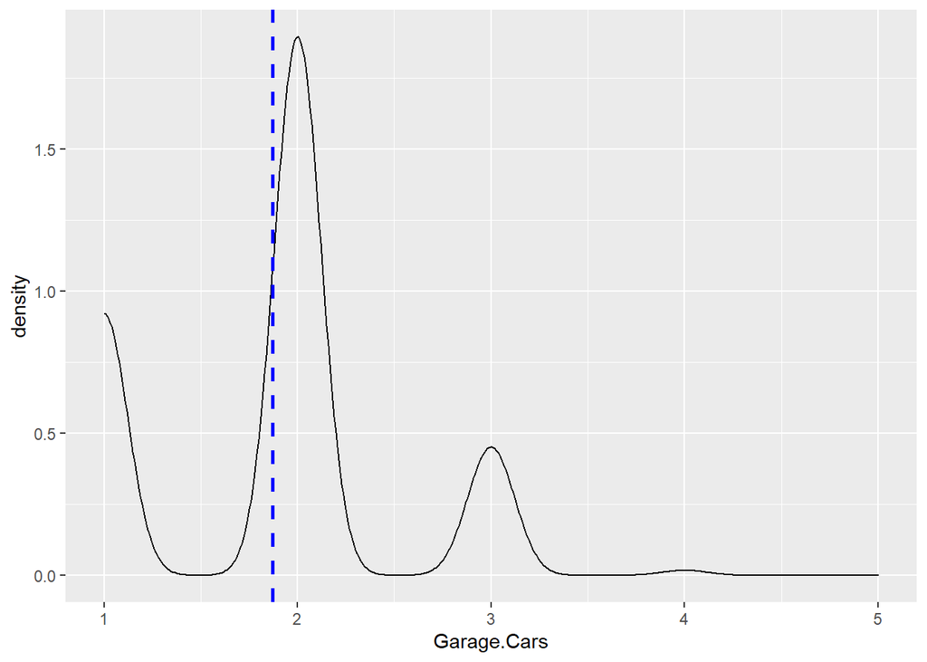

```r
p3 <- ggplot(df, aes(x=Garage.Cars)) +
  geom_density()
p3 + geom_vline(aes(xintercept=mean(Garage.Cars)),
            color="blue", linetype="dashed", size=1)
```

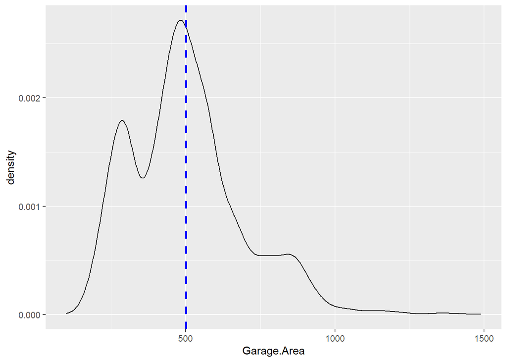

```r
p4 <- ggplot(df, aes(x=Garage.Area)) +
  geom_density()
p4 + geom_vline(aes(xintercept=mean(Garage.Area)),
            color="blue", linetype="dashed", size=1)
```

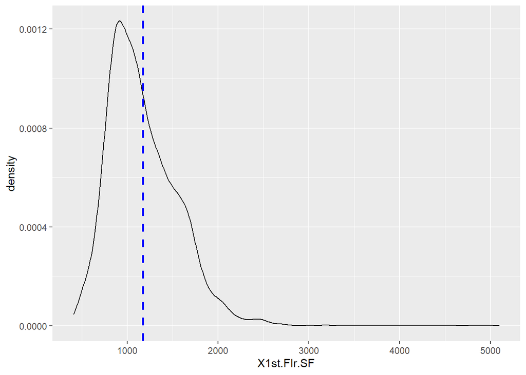

```r
p5 <- ggplot(df, aes(x=X1st.Flr.SF)) +
  geom_density()
p5 + geom_vline(aes(xintercept=mean(X1st.Flr.SF)),
            color="blue", linetype="dashed", size=1)
```

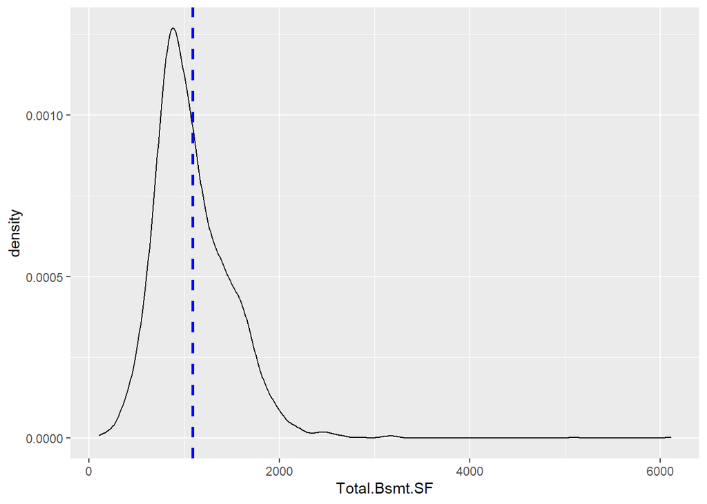

```r
p6 <- ggplot(df, aes(x=Total.Bsmt.SF)) +
  geom_density()
p6 + geom_vline(aes(xintercept=mean(Total.Bsmt.SF)),
            color="blue", linetype="dashed", size=1)
```

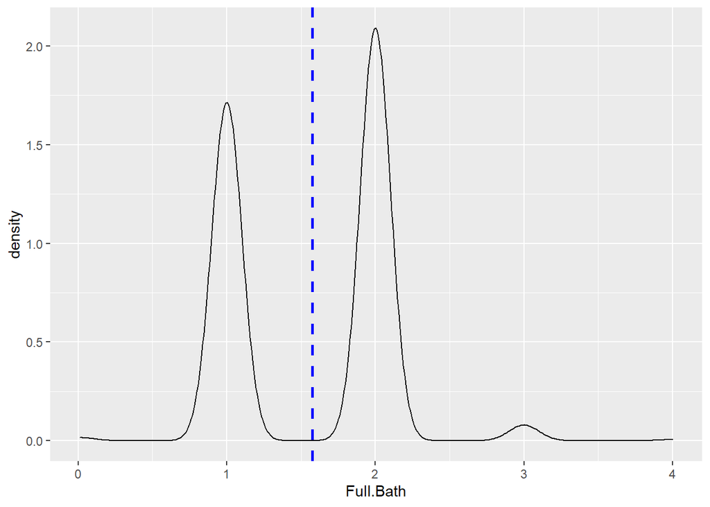

```r
p7 <- ggplot(df, aes(x=Full.Bath)) +
  geom_density()
p7 + geom_vline(aes(xintercept=mean(Full.Bath)),
            color="blue", linetype="dashed", size=1)
```

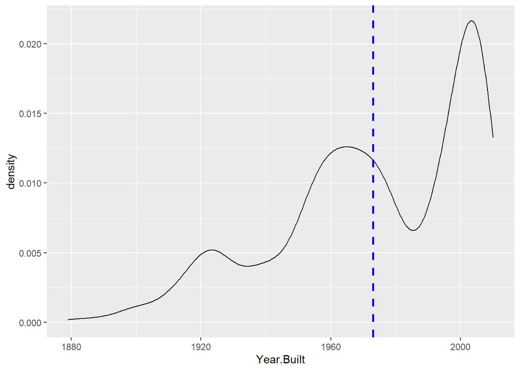

```r
p8 <- ggplot(df, aes(x=Year.Built)) +
  geom_density()
p8 + geom_vline(aes(xintercept=mean(Year.Built)),
            color="blue", linetype="dashed", size=1)
```

## 3.4. Inspecting price against numerical variables of interest

Overall.Qual, Gr.Liv.Area, Garage.Cars, Garage.Area, X1st.Flr.SF, Total.Bsmt.SF, Full.Bath, Year.Built

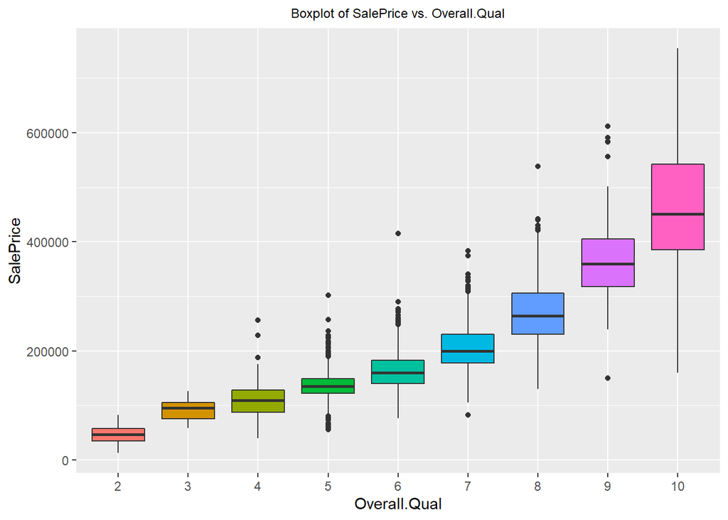

```r
g1 <- ggplot(df, aes(factor(Overall.Qual), SalePrice, fill=factor(Overall.Qual))) +
  geom_boxplot() +
  labs(x = "Overall.Qual", y = "SalePrice", title = "Boxplot of SalePrice vs. Overall.Qual") +
  theme(legend.position = 'none', plot.title = element_text(size = 9, hjust=0.5))
g1
```

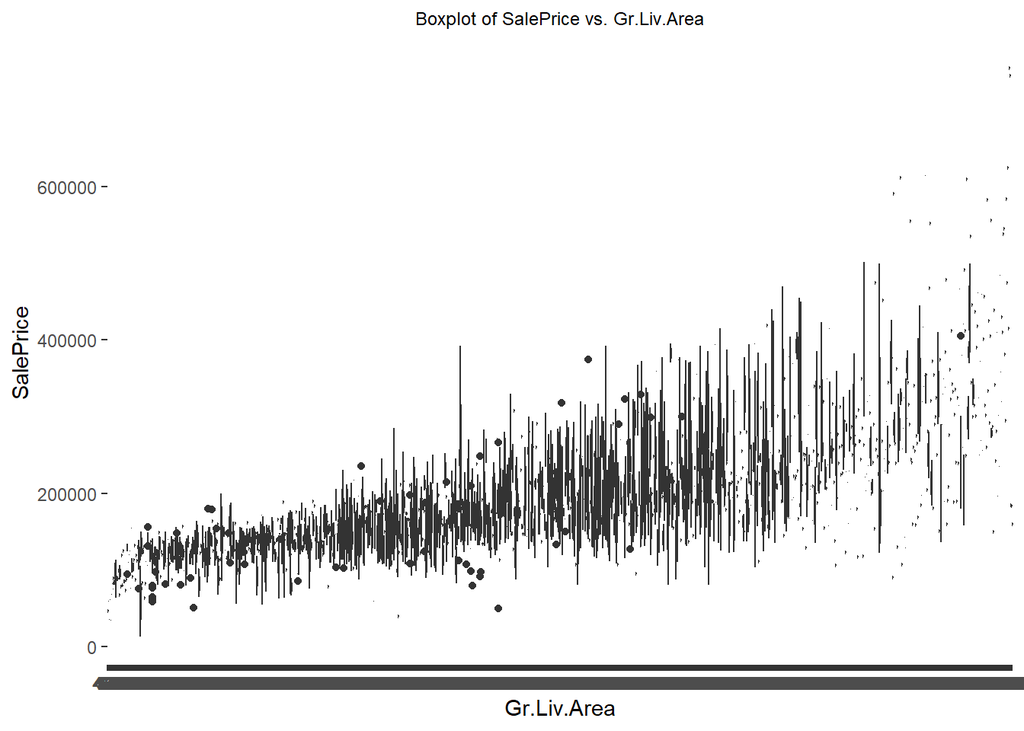

```r
g2 <- ggplot(df, aes(factor(Gr.Liv.Area), SalePrice, fill=factor(Gr.Liv.Area))) +
  geom_boxplot() +
  labs(x = "Gr.Liv.Area", y = "SalePrice", title = "Boxplot of SalePrice vs. Gr.Liv.Area") +
  theme(legend.position = 'none', plot.title = element_text(size = 9, hjust=0.5))
g2
```

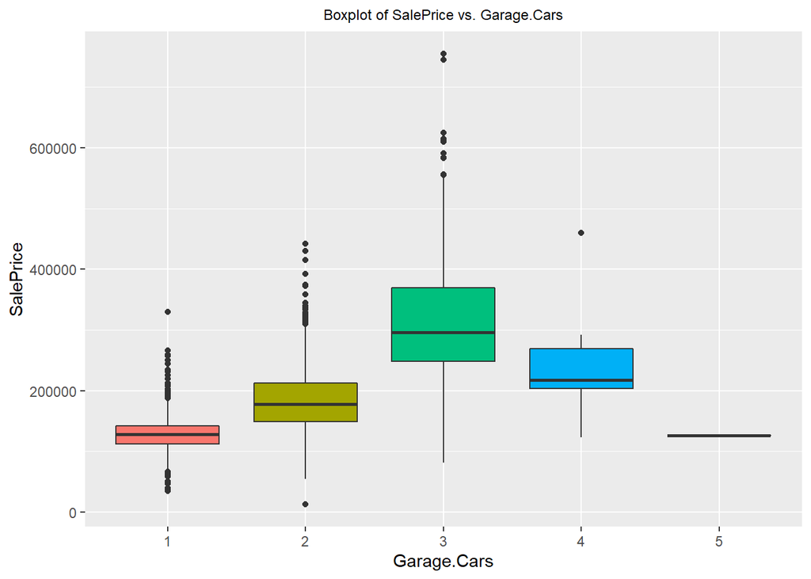

```r
g3 <- ggplot(df, aes(factor(Garage.Cars), SalePrice, fill=factor(Garage.Cars))) +
  geom_boxplot() +
  labs(x = "Garage.Cars", y = "SalePrice", title = "Boxplot of SalePrice vs. Garage.Cars") +
  theme(legend.position = 'none', plot.title = element_text(size = 9, hjust=0.5))
g3
```

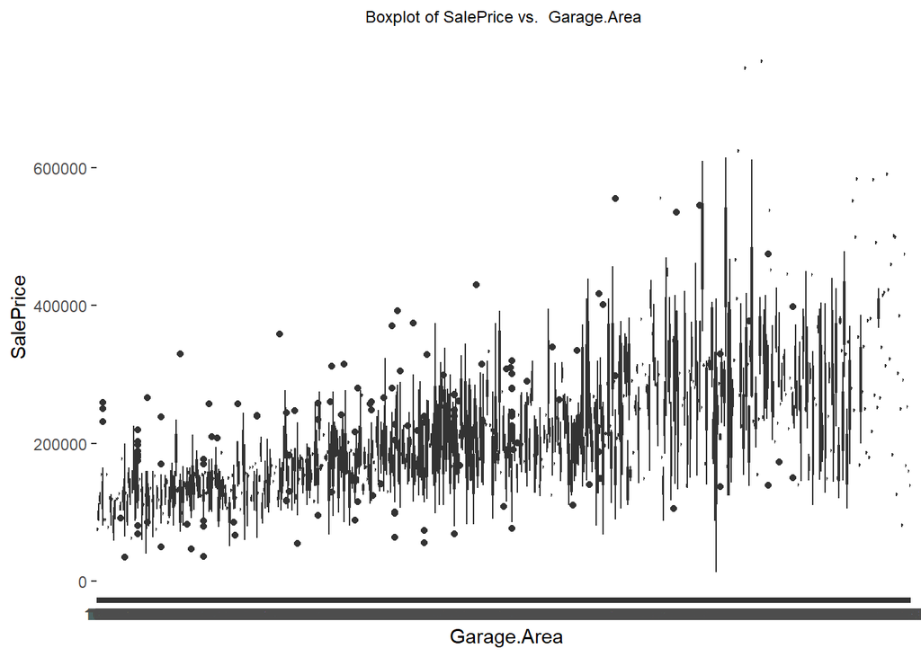

```r
g4 <- ggplot(df, aes(factor( Garage.Area), SalePrice, fill=factor( Garage.Area))) +
  geom_boxplot() +
  labs(x = " Garage.Area", y = "SalePrice", title = "Boxplot of SalePrice vs.  Garage.Area") +
  theme(legend.position = 'none', plot.title = element_text(size = 9, hjust=0.5))
g4
```

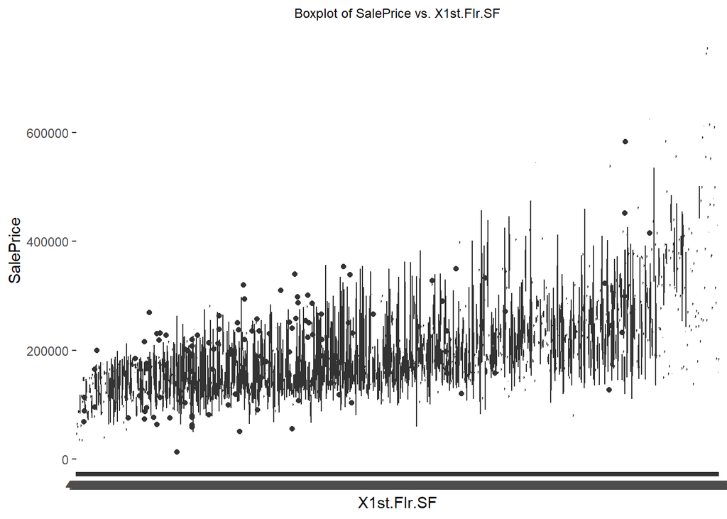

```r
g5 <- ggplot(df, aes(factor(X1st.Flr.SF), SalePrice, fill=factor(X1st.Flr.SF))) +
  geom_boxplot() +
  labs(x = "X1st.Flr.SF", y = "SalePrice", title = "Boxplot of SalePrice vs. X1st.Flr.SF") +
  theme(legend.position = 'none', plot.title = element_text(size = 9, hjust=0.5))
g5
```

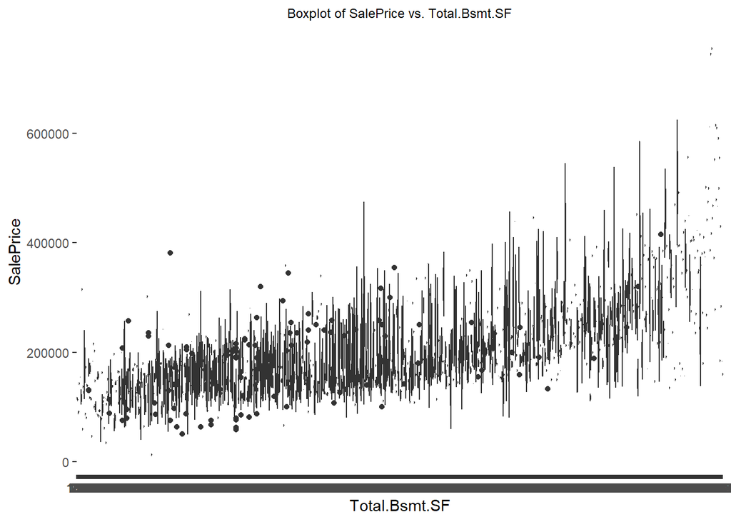

```r
g6 <- ggplot(df, aes(factor(Total.Bsmt.SF), SalePrice, fill=factor(Total.Bsmt.SF))) +
  geom_boxplot() +
  labs(x = "Total.Bsmt.SF", y = "SalePrice", title = "Boxplot of SalePrice vs. Total.Bsmt.SF") +
  theme(legend.position = 'none', plot.title = element_text(size = 9, hjust=0.5))
g6
```

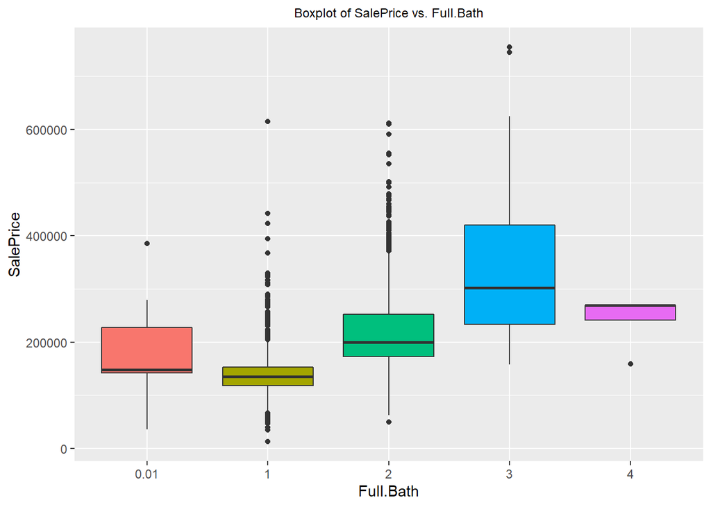

```r
g7 <- ggplot(df, aes(factor(Full.Bath), SalePrice, fill=factor(Full.Bath))) +
  geom_boxplot() +
  labs(x = "Full.Bath", y = "SalePrice", title = "Boxplot of SalePrice vs. Full.Bath") +
  theme(legend.position = 'none', plot.title = element_text(size = 9, hjust=0.5))
g7
```

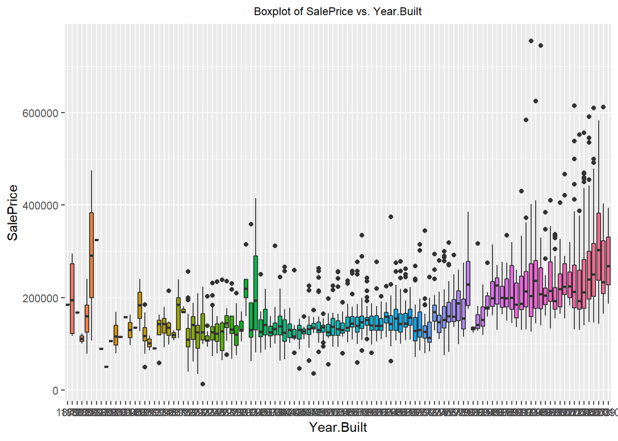

```r
g8 <- ggplot(df, aes(factor(Year.Built), SalePrice, fill=factor(Year.Built))) +
  geom_boxplot() +
  labs(x = "Year.Built", y = "SalePrice", title = "Boxplot of SalePrice vs. Year.Built") +
  theme(legend.position = 'none', plot.title = element_text(size = 9, hjust=0.5))
g8
```

## 3.5. Box-Cox transformation

```r
bc1 <- boxcox(lm(SalePrice~Overall.Qual, data=dfnew))
```

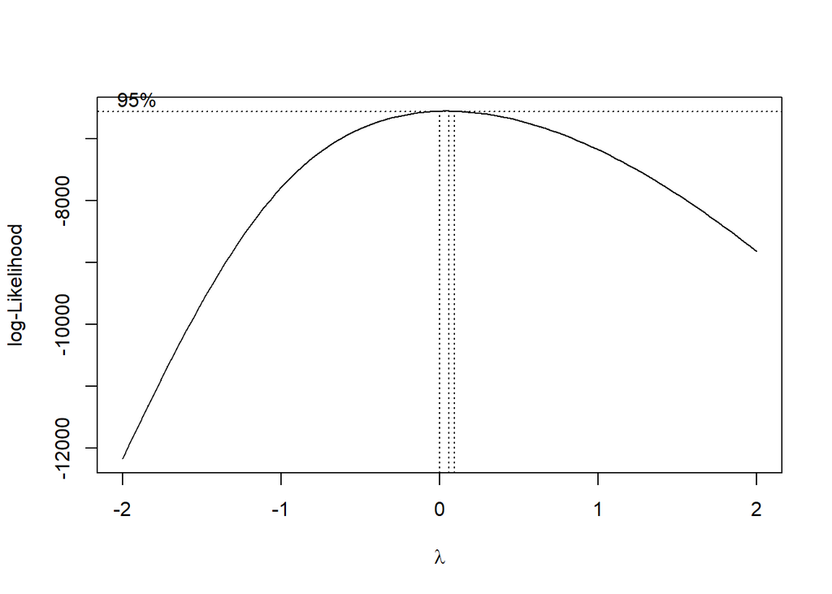

```r
bc2 <- boxcox(lm(SalePrice~Gr.Liv.Area, data=dfnew))
```

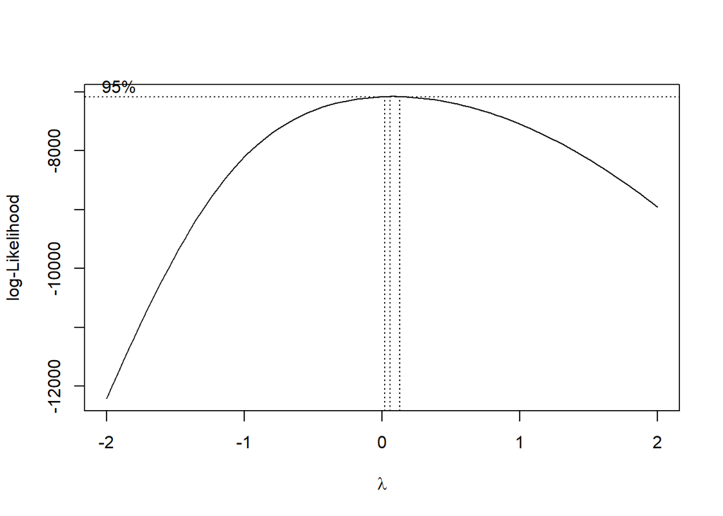

```r
bc3 <- boxcox(lm(SalePrice~Garage.Cars, data=dfnew))
```

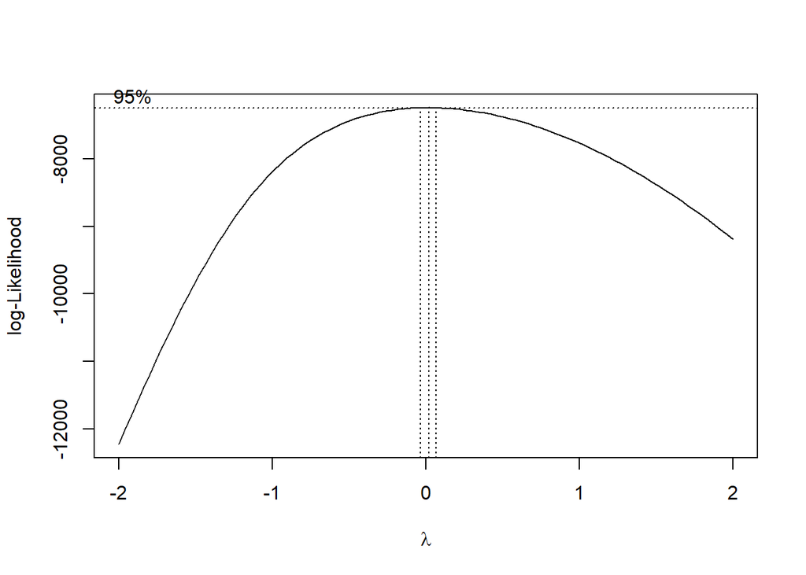

```r
bc4 <- boxcox(lm(SalePrice~Garage.Area, data=dfnew))
```

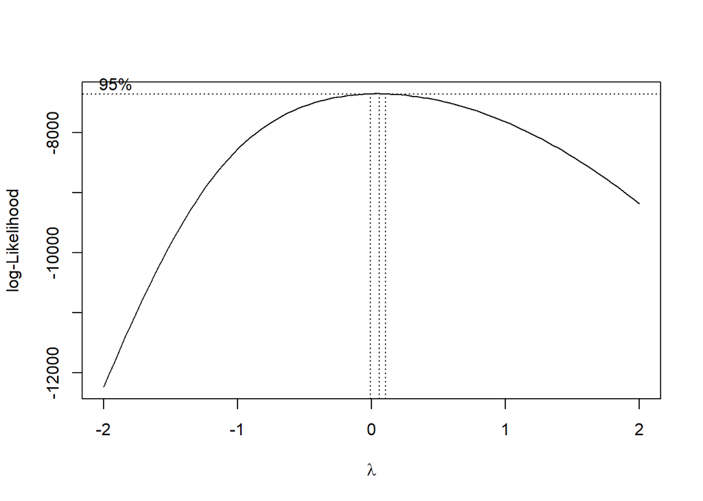